# Problema 4 - Checkpoint 1

Diogo Florêncio

# Os dados

Os dados compõe uma amostra de dados da atividade global do github, neles contém a contagem de quantas pessoas editaram arquivos para cada extensão de arquivo no período de 2016 à 2017. Estes dados estão disponíveis [aqui](https://raw.githubusercontent.com/nazareno/fpcc2/master/datasets/github-users-committing-filetypes.csv). Para essa análise as extensões consideradas foram `.html` e `.js`. Objetivo dessa análise é estudar a `popularidade` dessas extensões durante a semana e finais de semana.

```r
amostra <- read.csv("../dados/github-users-committing-filetypes.csv")
amostra = amostra %>%
        mutate(date = as.Date(paste(month_day,the_month,the_year),format = "%d %m %Y")) %>%
        mutate(week_day = (weekdays(as.Date(date))))%>%
        select(file_extension,week_day, date,users)
extension_html = amostra%>%
        filter(file_extension == "html")
extension_js = amostra%>%
        filter(file_extension == "js")
```

# Popularidade de `.html`

Para mensurar a popularidade da extensão `.html` considerei como parâmetro a quantidade média de edições, quanto mais popular for determinada extensão maior será sua média de edições. Análisando a amostra por meio do método bootstrap estimei valores médios da popularidade de `.html`, durante a semana e aos finais de semana, para toda a população do github. A análise foi realizada com confiança de 95%, o bootstrap gerou 10.000 reamostragens. Os resultados foram bem expressivos, a media de edições durante a semana foi estimada em [4504.764 ; 4635.792] e aos finais [2878.936 ; 3032.271].

```r
dist_html_fds = filter(extension_html, week_day %in% c("sábado","domingo")) %>%
    bootstrap(mean(users)) %>%
    CI.percentile(probs = c(.025, .975)) %>%
    as.data.frame()%>%
    mutate(week_day = "fim de semana")
dist_html = filter(extension_html, !(week_day %in% c("sábado","domingo"))) %>%
    bootstrap(mean(users)) %>%
    CI.percentile(probs = c(.025, .975)) %>%
    as.data.frame()%>%
    mutate(week_day = "semana")
df = data.frame(rbind(dist_html,
                      dist_html_fds))
df
```

| X2.5. | X97.5. | week_day |
| --- | --- | --- |
| 4506.087 | 4636.791 | semana |
| 2876.731 | 3033.025 | fim de semana |

## Resultados

A diferença de popularidade durante a semana é significativamente maior do que aos finais para `.html`. Por meio da razão entre os pontos médios dos intervalos estimados para popularidade (4635,792/3032.271 = 1,5288), pode-se dizer que durante a semana a popularidade de `.html` é em torno de 1.5 vezes maior do que aos finais de semana. Graficamente essa diferença de popularidade é bem significativa.

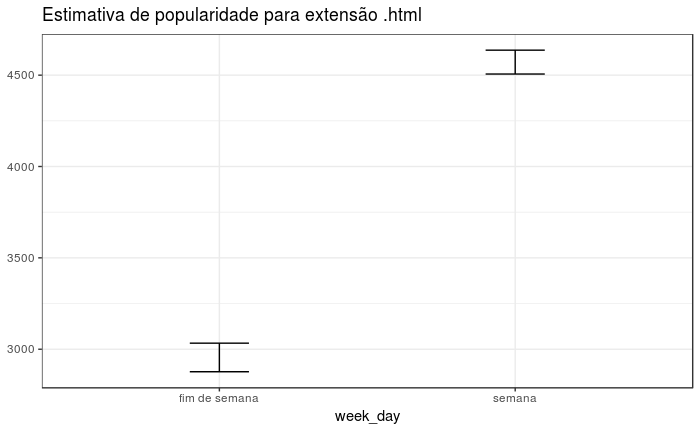

```r
df %>%
  ggplot(aes(x = week_day, ymin = X2.5., ymax = X97.5.)) +
  geom_errorbar(width = .2) +
  ggtitle("Estimativa de popularidade para extensão .html")
```

Este resultado é relevante para determinar em quais contextos html é mais utilizado. Como durante a semana html é bem mais popular podemos suspeitar que a extensão é mais utilizada em ambientes de trabalho, ou seja, talvez html não seja uma extensão de fim de semana normalmente usada em projetos pessoais ou coisas do tipo.

# Popularidade `.js`

Conforme feito para extensão anterior, o parâmetro considerado como índice de popularidade para `.js` foi a quantidade média de edições. Análisando a amostra por meio do método bootstrap estimei valores médios da popularidade, durante a semana e aos finais de semana, para toda a população do github. A análise foi realizada com a mesma confiança da anterior 95%, o bootstrap também gerou 10.000 reamostragens. A média de edições durante a semana foi estimada em [6925.225 ; 7141.665] e aos finais [4085.395 ; 4304.063].

```r
dist_js_fds = filter(extension_js, week_day %in% c("sábado","domingo")) %>%
    bootstrap(mean(users)) %>%
    CI.percentile(probs = c(.025, .975))%>%
    as.data.frame()%>%
    mutate(week_day = "fim de semana")
dist_js = filter(extension_js, !(week_day %in% c("sábado","domingo"))) %>%
    bootstrap(mean(users)) %>%
    CI.percentile(probs = c(.025, .975))%>%
    as.data.frame()%>%
    mutate(week_day = "semana")
df = data.frame(rbind(dist_js,
                      dist_js_fds))
df
```

| X2.5. | X97.5. | week_day |
| --- | --- | --- |
| 6926.841 | 7138.544 | semana |
| 4089.880 | 4303.284 | fim de semana |

## Resultados

A diferença de popularidade durante a semana é significativamente maior do que aos finais para `.js`. Novamente, por meio da razão entre os pontos médios dos intervalos estimados para popularidade (7141.665/4304.063 = 1,6592), pode-se dizer que durante a semana a popularidade de `.js` é em torno de 1.6 vezes maior do que aos finais de semana. Graficamente essa diferença de popularidade é bem significativa.

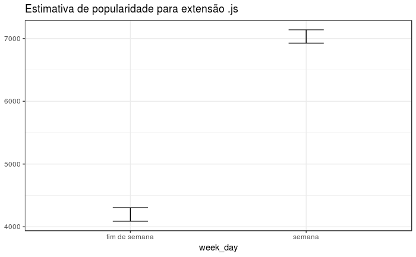

```r
df %>%
  ggplot(aes(x = week_day, ymin = X2.5., ymax = X97.5.)) +
  geom_errorbar(width = .2)+
  ggtitle("Estimativa de popularidade para extensão .js")
```

Este resultado é relevante para determinar em quais contextos js é mais utilizado. Mesmo sendo bem mais popular durante a semana js ainda apresenta grande popularidade aos finais de semana quando comparado com html por exemplo, graficamente essa diferença de popularidade é bem significativa.

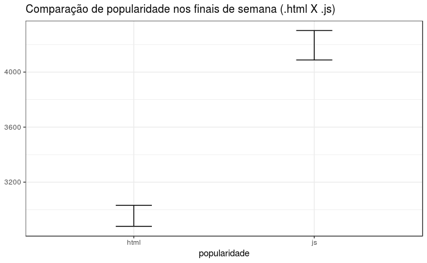

```r
dist_html_fds = filter(extension_html, week_day %in% c("sábado","domingo")) %>%
    bootstrap(mean(users)) %>%
    CI.percentile(probs = c(.025, .975)) %>%
    as.data.frame()%>%
    mutate(popularidade = "html")
dist_js_fds = filter(extension_js, week_day %in% c("sábado","domingo")) %>%
    bootstrap(mean(users)) %>%
    CI.percentile(probs = c(.025, .975))%>%
    as.data.frame()%>%
    mutate(popularidade = "js")
df = data.frame(rbind(dist_html_fds,
                      dist_js_fds))
df %>%
  ggplot(aes(x = popularidade, ymin = X2.5., ymax = X97.5.)) +
  geom_errorbar(width = .2)+
  ggtitle("Comparação de popularidade nos finais de semana (.html X .js)")
```

Por tanto, podemos concluir que js é popular tanto aos finais de semana como durante a semana. Com isso, podemos inferir que js é utilizado tanto em contextos como ambientes de trabalho, como em projetos pessoais, estudos e coisas do gênero. Essa popularidade pode ser justificada também atrávez da grande quantidade de frameworks construidos em js.

# Variância da popularidade nos finais de semana `.html` X `.js`

A diferença para a variância na popularidade das duas extensões nos finais de semana também é bastante significativa, a estimativa da variância para html foi [158198.2 ; 279791.3] e para js [304905.5 ; 552105.6]. Como em todas as análises anteriores, o nível de confiança considerado foi 95%, o bootstrap também gerou 10.000 reamostragens.

```r
dist_html_fds = filter(extension_html, week_day %in% c("sábado","domingo")) %>%
    bootstrap(var(users)) %>%
    CI.percentile(probs = c(.025, .975))%>%
    as.data.frame()%>%
    mutate(variancia = "html")
dist_js_fds = filter(extension_js, week_day %in% c("sábado","domingo")) %>%
    bootstrap(var(users)) %>%
    CI.percentile(probs = c(.025, .975))%>%
    as.data.frame()%>%
    mutate(variancia = "js")
df = data.frame(rbind(dist_html_fds,
                      dist_js_fds))
df
```

| X2.5. | X97.5. | variancia |
| --- | --- | --- |
| 158894.8 | 277815.2 | html |
| 303325.0 | 550952.5 | js |

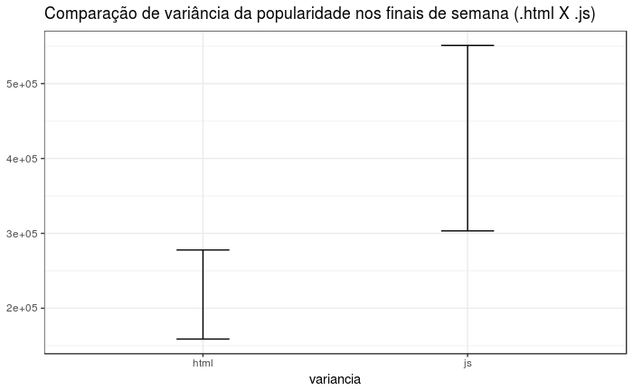

```r
df %>%
  ggplot(aes(x = variancia, ymin = X2.5., ymax = X97.5.)) +
  geom_errorbar(width = .2)+
  ggtitle("Comparação de variância da popularidade nos finais de semana (.html X .js)")
```